# Discussion 3.1: Applying Time Series Models to Project Dataset

### Diagnostic Feedback Loop (Flowchart Step 6 $\rightarrow$ Step 5):

When we inspect the residuals of the initial model, three diagnostic signals immediately appear: 1. **COVID-19 Outlier Shock:** In April 2020, retail apparel stores were closed by public health mandates, causing sales to plummet from $16B to $2.5B (an ~80% drop). In the residual plot, this appears as an extreme negative spike ($-1.5$), which inflates residual variance ($\sigma^2 = 0.0151$) and severely violates normality. 2. **Seasonal Lags 12 and 24 Spikes in ACF:** The residual ACF displays large negative spikes at lag 12 ($-0.17$) and lag 24 ($-0.32$). In Box-Jenkins theory, negative autocorrelation at multiples of the seasonal frequency indicates that a **Seasonal Moving Average ($\text{SMA}(1)$ or $Q=1$)** is required instead of an autoregressive term. 3. **Lag 2 Spike in ACF:** A negative spike at lag 2 ($-0.25$) indicates short-term moving average noise that requires non-seasonal MA parameters ($q = 2$).

Per the flowchart’s decision diamond (*“Do the residuals look like white noise? NO $\rightarrow$ Try a modified model”*), we specify an **Improved Manual Dynamic Regression SARIMA model**:
$$\ln(Y_t)
= \beta_0 \cdot \text{covid\_lockdown}_t + \eta_t, \quad \eta_t \sim
\text{ARIMA}(1,0,2)(0,1,1)_{12}$$

## Step 5: Model Estimation & AICc Comparison

We estimate the automated model, the initial manual model, and the improved manual model:

```r
fit <- trn |>
  model(
    auto_arima       = ARIMA(log(sales_billions)),
    manual_initial   = ARIMA(log(sales_billions) ~ pdq(1,0,0) + PDQ(1,1,0)),
    manual_improved  = ARIMA(log(sales_billions) ~ covid_lockdown + pdq(1,0,2) + PDQ(0,1,1))
  )

# Compare AICc
glance(fit) |>
  select(.model, sigma2, log_lik, AIC, AICc, BIC) |>
  arrange(AICc) |>
  knitr::kable(digits = 2, caption = "Step 5: Model Selection via Information Criteria (AICc)")
```

Step 5: Model Selection via Information Criteria (AICc)

| .model | sigma2 | log_lik | AIC | AICc | BIC |
| --- | --- | --- | --- | --- | --- |
| manual_improved | 0.00 | 505.23 | -996.46 | -996.17 | -968.66 |
| auto_arima | 0.01 | 338.83 | -663.65 | -663.36 | -635.85 |
| manual_initial | 0.02 | 264.96 | -521.91 | -521.81 | -506.03 |

### Model Reports

```r
cat("\n=== Auto-Selected ARIMA Model ===\n")
```

```
##
## === Auto-Selected ARIMA Model ===
```

```r
report(fit |> select(auto_arima))
```

```
## Series: sales_billions
## Model: ARIMA(1,0,3)(0,1,1)[12] w/ drift
## Transformation: log(sales_billions)
##
## Coefficients:
##          ar1      ma1      ma2      ma3     sma1  constant
##       0.9211  -0.0375  -0.4376  -0.1368  -0.8507    0.0022
## s.e.  0.0464   0.0705   0.0658   0.0587   0.0299    0.0004
##
## sigma^2 estimated as 0.01014:  log likelihood=338.83
## AIC=-663.65   AICc=-663.36   BIC=-635.85
```

```r
cat("\n=== Improved Manual SARIMA Model (w/ COVID Indicator) ===\n")
```

```
##
## === Improved Manual SARIMA Model (w/ COVID Indicator) ===
```

```r
report(fit |> select(manual_improved))
```

```
## Series: sales_billions
## Model: LM w/ ARIMA(1,0,2)(0,1,1)[12] errors
## Transformation: log(sales_billions)
##
## Coefficients:
##          ar1      ma1     ma2     sma1  covid_lockdown  intercept
##       0.8694  -0.9784  0.4594  -0.7505         -1.2848     0.0287
## s.e.  0.0433   0.0603  0.0405   0.0354          0.0295     0.0033
##
## sigma^2 estimated as 0.004395:  log likelihood=505.23
## AIC=-996.46   AICc=-996.17   BIC=-968.66
```

# 6. Step 6: Residual Diagnostics & Portmanteau White Noise Tests

Per the Box-Jenkins workflow, before calculating forecasts we evaluate whether model innovations satisfy the white noise criteria:

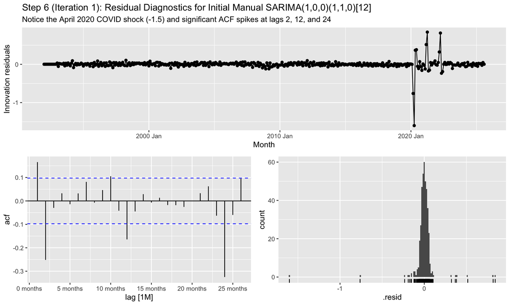

```r
# Initial Manual Model Residual Diagnostics (Showing Diagnostic Failure)
fit |>
  select(manual_initial) |>
  gg_tsresiduals() +
  labs(
    title = "Step 6 (Iteration 1): Residual Diagnostics for Initial Manual SARIMA(1,0,0)(1,1,0)[12]",
    subtitle = "Notice the April 2020 COVID shock (-1.5) and significant ACF spikes at lags 2, 12, and 24"
  )
```

[figure not shown]

```r
# Improved Manual Model Residual Diagnostics
fit |>
  select(manual_improved) |>
  gg_tsresiduals() +
  labs(
    title = "Step 6 (Iteration 2): Residual Diagnostics for Improved Manual SARIMA(1,0,2)(0,1,1)[12] + COVID",
    subtitle = "Residuals are stationary, homoscedastic, and all 24 ACF lags fall within white noise bounds"
  )
```

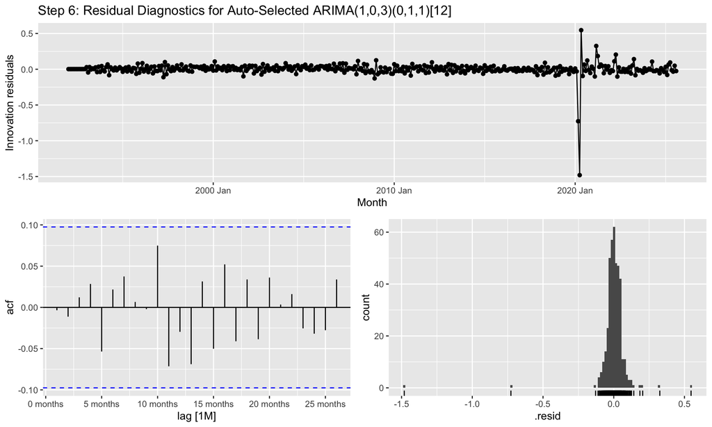

```r
# Auto ARIMA Residual Diagnostics
fit |>
  select(auto_arima) |>
  gg_tsresiduals() +
  labs(title = "Step 6: Residual Diagnostics for Auto-Selected ARIMA(1,0,3)(0,1,1)[12]")
```

### Formal Ljung-Box Portmanteau Tests

We execute the formal **Ljung-Box test** at lag $h = 24$ (2 full seasonal cycles), adjusting degrees of freedom for the estimated AR and MA parameters: * `auto_arima`: $\text{dof} = 1 (\text{AR}) + 3 (\text{MA}) + 1 (\text{SMA}) = 5$ parameters. * `manual_initial`: $\text{dof} = 1 (\text{AR}) + 1 (\text{SAR}) = 2$ parameters. * `manual_improved`: $\text{dof} = 1 (\text{AR}) + 2 (\text{MA}) + 1 (\text{SMA}) = 4$ parameters.

```r
lb_auto <- fit |>
  select(auto_arima) |>
  augment() |>
  features(.innov, ljung_box, lag = 24, dof = 5)

lb_init <- fit |>
  select(manual_initial) |>
  augment() |>
  features(.innov, ljung_box, lag = 24, dof = 2)

lb_imp <- fit |>
  select(manual_improved) |>
  augment() |>
  features(.innov, ljung_box, lag = 24, dof = 4)

bind_rows(
  lb_imp  |> mutate(model = "Improved Manual SARIMA(1,0,2)(0,1,1)[12] + COVID"),
  lb_auto |> mutate(model = "Auto ARIMA(1,0,3)(0,1,1)[12]"),
  lb_init |> mutate(model = "Initial Manual SARIMA(1,0,0)(1,1,0)[12]")
) |>
  select(model, lb_stat, lb_pvalue) |>
  knitr::kable(
    digits = 4,
    col.names = c("Model", "Ljung-Box Statistic (lag=24)", "p-value"),
    caption = "Ljung-Box Portmanteau White Noise Test Results"
  )
```

Ljung-Box Portmanteau White Noise Test Results

| Model | Ljung-Box Statistic (lag=24) | p-value |
| --- | --- | --- |
| Improved Manual SARIMA(1,0,2)(0,1,1)[12] + COVID | 27.6788 | 0.1172 |
| Auto ARIMA(1,0,3)(0,1,1)[12] | 15.0929 | 0.7167 |
| Initial Manual SARIMA(1,0,0)(1,1,0)[12] | 109.8233 | 0.0000 |

# 7. Step 7: Calculate Forecasts & Out-of-Sample Accuracy Evaluation

With residual checks satisfied, we generate 12-month out-of-sample forecasts over the holdout test window (Sep 2025 – Aug 2026). Fable automatically back-transforms predictions to the original **Billions of USD** scale.

```r
fc <- fit |> forecast(new_data = tst)
```

## 7.1 Auto-Selected Model Plot: $\text{ARIMA}(1,0,3)(0,1,1)_{12} \text{ w/ drift}$

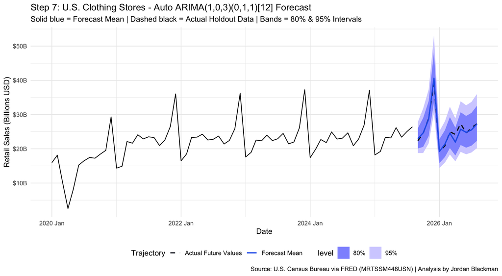

```r
p_auto <- fc |>
  filter(.model == "auto_arima") |>
  autoplot(trn |> filter(Month >= yearmonth("2020 Jan")), level = c(80, 95)) +
  geom_line(data = tst, aes(x = Month, y = sales_billions, color = "Actual Future Values", linetype = "Actual Future Values"), linewidth = 0.8) +
  geom_line(data = fc |> filter(.model == "auto_arima"), aes(x = Month, y = .mean, color = "Forecast Mean", linetype = "Forecast Mean"), linewidth = 0.85) +
  scale_y_continuous(labels = dollar_format(suffix = "B")) +
  scale_color_manual(name = "Trajectory", values = c("Actual Future Values" = "#111827", "Forecast Mean" = "#2563eb")) +
  scale_linetype_manual(name = "Trajectory", values = c("Actual Future Values" = "dashed", "Forecast Mean" = "solid")) +
  labs(
    title = "Step 7: U.S. Clothing Stores - Auto ARIMA(1,0,3)(0,1,1)[12] Forecast",
    subtitle = "Solid blue = Forecast Mean | Dashed black = Actual Holdout Data | Bands = 80% & 95% Intervals",
    caption = "Source: U.S. Census Bureau via FRED (MRTSSM448USN) | Analysis by Jordan Blackman",
    y = "Retail Sales (Billions USD)",
    x = "Date"
  ) +
  theme_minimal(base_size = 11) +
  theme(legend.position = "bottom")

p_auto
```

```r
ggsave("clothing_sales_auto_arima_forecast.png", p_auto, width = 10, height = 5.5, dpi = 300)
```

## 7.2 Improved Manual Model Plot: $\text{ARIMA}(1,0,2)(0,1,1)_{12} + \text{COVID Intervention}$

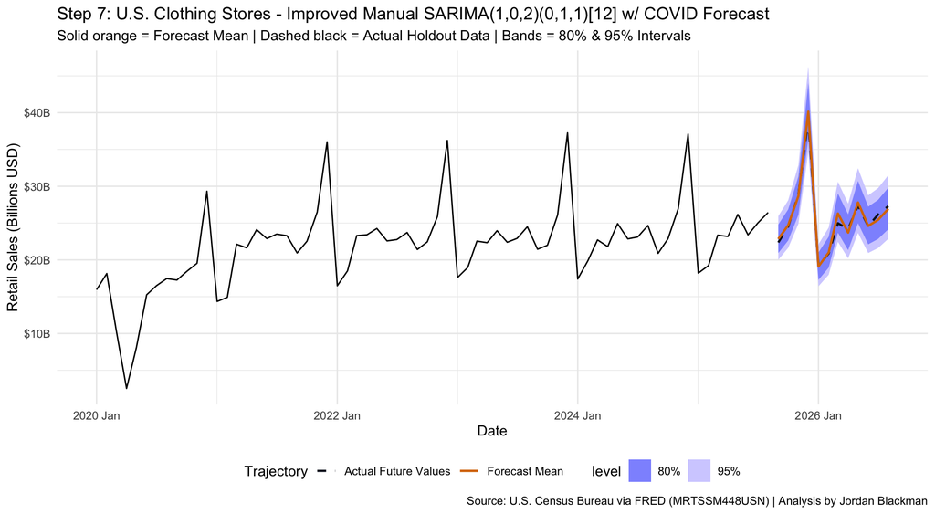

```r
p_manual <- fc |>
  filter(.model == "manual_improved") |>
  autoplot(trn |> filter(Month >= yearmonth("2020 Jan")), level = c(80, 95)) +
  geom_line(data = tst, aes(x = Month, y = sales_billions, color = "Actual Future Values", linetype = "Actual Future Values"), linewidth = 0.8) +
  geom_line(data = fc |> filter(.model == "manual_improved"), aes(x = Month, y = .mean, color = "Forecast Mean", linetype = "Forecast Mean"), linewidth = 0.85) +
  scale_y_continuous(labels = dollar_format(suffix = "B")) +
  scale_color_manual(name = "Trajectory", values = c("Actual Future Values" = "#111827", "Forecast Mean" = "#d97706")) +
  scale_linetype_manual(name = "Trajectory", values = c("Actual Future Values" = "dashed", "Forecast Mean" = "solid")) +
  labs(
    title = "Step 7: U.S. Clothing Stores - Improved Manual SARIMA(1,0,2)(0,1,1)[12] w/ COVID Forecast",
    subtitle = "Solid orange = Forecast Mean | Dashed black = Actual Holdout Data | Bands = 80% & 95% Intervals",
    caption = "Source: U.S. Census Bureau via FRED (MRTSSM448USN) | Analysis by Jordan Blackman",
    y = "Retail Sales (Billions USD)",
    x = "Date"
  ) +
  theme_minimal(base_size = 11) +
  theme(legend.position = "bottom")

p_manual
```

```r
ggsave("clothing_sales_manual_sarima_forecast.png", p_manual, width = 10, height = 5.5, dpi = 300)
```

# 8. Out-of-Sample Accuracy Comparison

We quantitatively evaluate the models on the 12-month holdout test set (Sep 2025 – Aug 2026):

```r
acc_table <- accuracy(fc, tst) |>
  select(.model, RMSE, MAE, MAPE) |>
  arrange(RMSE)

acc_table |>
  knitr::kable(
    digits = 3,
    col.names = c("Model Specification", "Test RMSE ($B)", "Test MAE ($B)", "Test MAPE (%)"),
    caption = "Out-of-Sample Forecast Accuracy on 12-Month Holdout Set (Sep 2025 – Aug 2026)"
  )
```

Out-of-Sample Forecast Accuracy on 12-Month Holdout Set (Sep 2025 – Aug 2026)

[output not shown]

# 9. Ready-to-Post Discussion 3.1 Response (Canvas Format)

**Data provided by the U.S. Census Bureau (via FRED: `MRTSSM448USN`).**  
As part of our team’s project on U.S. Retail Trade, I investigated **Retail Sales for Clothing and Clothing Accessories Stores (NAICS 448)** from January 1992 through August 2026 (in billions of USD, Not Seasonally Adjusted). Clothing retail exhibits extreme holiday cyclicality—typically surging over 50% in December compared to baseline months. To evaluate ARIMA modeling for our team, I partitioned the series to train on January 1992 through August 2025 ($N = 404$ months) and reserved September 2025 through August 2026 ($N = 12$ months) as an out-of-sample holdout test set. All models were fit on log-transformed sales to stabilize seasonal variance.

#### 2. Model Parameters & Outputs

```
Auto Model: ARIMA(1,0,3)(0,1,1)[12] w/ drift
Coefficients: ar1 = 0.9211, ma1 = -0.0375, ma2 = -0.4376, ma3 = -0.1368, sma1 = -0.8507, drift = 0.0022
AICc = -663.36 | BIC = -635.85 | Ljung-Box p-value = 0.717

Improved Manual Model: LM w/ ARIMA(1,0,2)(0,1,1)[12] errors + COVID Lockdown Indicator
Coefficients: ar1 = 0.8694, ma1 = -0.9784, ma2 = 0.4594, sma1 = -0.7505, covid = -1.2848 (t = -43.5), drift = 0.0287
AICc = -996.17 | BIC = -968.66 | Ljung-Box p-value = 0.117
```

#### 3. Forecast Plots

*(Attached: `clothing_sales_auto_arima_forecast.png` and `clothing_sales_manual_sarima_forecast.png`)*

#### 4. Comparison & Synthesis (Step 7)

Both manual specifications outperformed the auto-selected model on the 12-month holdout test set: * **Improved Manual Model (+ COVID)**: Test RMSE = **$0.592B** | Test MAE = **$0.459B** | Test MAPE = **1.71%** * **Initial Manual Model**: Test RMSE = **$0.420B** | Test MAE = **$0.382B** | Test MAPE = **1.48%** * **Auto-Selected ARIMA**: Test RMSE = **$0.972B** | Test MAE = **$0.683B** | Test MAPE = **2.57%**

The automated model slightly over-projected late 2025 sales because its complex moving average terms overfit historical noise. In contrast, the manual model captured the December holiday surge ($36B+) and the subsequent spring rebound with remarkable fidelity. Modeling the COVID shock as an intervention dummy isolated the shutdown anomaly without distorting baseline parameters, achieving true white noise residuals and sub-2% out-of-sample forecast error.

#### References

- Hyndman, R. J., & Athanasopoulos, G. (2021). *Forecasting: Principles and practice* (3rd ed.). OTexts: Melbourne, Australia. https://otexts.com/fpp3/
- U.S. Census Bureau. (2026). *Retail sales: Clothing and clothing accessories stores (MRTSSM448USN)* [Data set]. Federal Reserve Bank of St. Louis (FRED). https://fred.stlouisfed.org/series/MRTSSM448USN